# Electricity/Solar Update

A look at the latest Jedlovec House eletricity usage and solar production from PPL and Enphase.

Load packages

```r
library(tidyverse)
library(lubridate)
library(hms)
library(readxl)
library(onlineBcp)
```

Load PPL data

| Account Number | Meter Number | Date | Read Type | Min | Max | Total | 12:00 AM | 12:15 AM | 12:30 AM | 12:45 AM | 1:00 AM | 1:15 AM | 1:30 AM | 1:45 AM | 2:00 AM | 2:15 AM | 2:30 AM | 2:45 AM | 3:00 AM | 3:15 AM | 3:30 AM | 3:45 AM | 4:00 AM | 4:15 AM | 4:30 AM | 4:45 AM | 5:00 AM | 5:15 AM | 5:30 AM | … |
| --- | --- | --- | --- | --- | --- | --- | --- | --- | --- | --- | --- | --- | --- | --- | --- | --- | --- | --- | --- | --- | --- | --- | --- | --- | --- | --- | --- | --- | --- | --- |
| 8892170024 | 300676415 | 2024-05-09 | kWh Net | -1.79 | 0.51 | -31.21 | 0.09 | 0.09 | 0.12 | 0.10 | 0.08 | 0.08 | 0.06 | 0.07 | 0.09 | 0.08 | 0.07 | 0.08 | 0.09 | 0.09 | 0.10 | 0.12 | 0.11 | 0.17 | 0.20 | 0.19 | 0.16 | 0.17 | 0.16 | … |
| 8892170024 | 300676415 | 2024-05-08 | kWh Net | -2.53 | 0.66 | -57.60 | 0.12 | 0.09 | 0.08 | 0.15 | 0.16 | 0.14 | 0.16 | 0.17 | 0.17 | 0.18 | 0.20 | 0.20 | 0.19 | 0.21 | 0.20 | 0.20 | 0.20 | 0.16 | 0.08 | 0.09 | 0.08 | 0.06 | 0.06 | … |
| 8892170024 | 300676415 | 2024-05-07 | kWh Net | -2.21 | 3.05 | -12.56 | 0.21 | 0.20 | 0.19 | 0.19 | 0.22 | 0.22 | 0.11 | 0.11 | 0.11 | 0.06 | 0.07 | 0.09 | 0.08 | 0.06 | 0.08 | 0.10 | 0.10 | 0.11 | 0.12 | 0.11 | 0.11 | 0.10 | 0.07 | … |
| 8892170024 | 300676415 | 2024-05-06 | kWh Net | -1.65 | 1.58 | -23.32 | 0.08 | 0.10 | 0.08 | 0.10 | 0.12 | 0.16 | 0.07 | 0.21 | 0.12 | 0.07 | 0.08 | 0.23 | 0.08 | 0.09 | 0.12 | 0.22 | 0.10 | 0.11 | 0.08 | 0.19 | 0.09 | 0.06 | 0.06 | … |
| 8892170024 | 300676415 | 2024-05-05 | kWh Net | -0.39 | 1.32 | 16.14 | 0.12 | 0.15 | 0.15 | 0.14 | 0.15 | 0.11 | 0.10 | 0.11 | 0.11 | 0.10 | 0.10 | 0.09 | 0.08 | 0.09 | 0.12 | 0.11 | 0.11 | 0.12 | 0.08 | 0.08 | 0.10 | 0.07 | 0.08 | … |
| 8892170024 | 300676415 | 2024-05-04 | kWh Net | -1.25 | 0.22 | -15.10 | 0.20 | 0.22 | 0.20 | 0.21 | 0.22 | 0.19 | 0.17 | 0.20 | 0.20 | 0.19 | 0.20 | 0.20 | 0.20 | 0.14 | 0.09 | 0.08 | 0.09 | 0.09 | 0.06 | 0.07 | 0.12 | 0.09 | 0.09 | … |
| 8892170024 | 300676415 | 2024-05-03 | kWh Net | -2.43 | 2.23 | -3.83 | 0.21 | 0.17 | 0.09 | 0.09 | 0.06 | 0.06 | 0.07 | 0.06 | 0.08 | 0.07 | 0.07 | 0.13 | 0.11 | 0.09 | 0.10 | 0.09 | 0.10 | 0.09 | 0.06 | 0.08 | 0.07 | 0.06 | 0.08 | … |
| 8892170024 | 300676415 | 2024-05-02 | kWh Net | -2.55 | 0.48 | -73.21 | 0.10 | 0.08 | 0.09 | 0.08 | 0.08 | 0.09 | 0.07 | 0.07 | 0.08 | 0.07 | 0.10 | 0.10 | 0.09 | 0.10 | 0.09 | 0.09 | 0.08 | 0.07 | 0.07 | 0.10 | 0.08 | 0.15 | 0.18 | … |
| 8892170024 | 300676415 | 2024-05-01 | kWh Net | -2.65 | 0.48 | -74.04 | 0.10 | 0.06 | 0.08 | 0.09 | 0.08 | 0.08 | 0.06 | 0.07 | 0.09 | 0.09 | 0.09 | 0.11 | 0.10 | 0.10 | 0.08 | 0.06 | 0.07 | 0.08 | 0.06 | 0.08 | 0.09 | 0.09 | 0.11 | … |
| 8892170024 | 300676415 | 2024-04-30 | kWh Net | -2.59 | 0.57 | -36.16 | 0.18 | 0.17 | 0.18 | 0.46 | 0.20 | 0.21 | 0.21 | 0.44 | 0.22 | 0.20 | 0.22 | 0.28 | 0.22 | 0.22 | 0.22 | 0.39 | 0.21 | 0.19 | 0.12 | 0.09 | 0.09 | 0.07 | 0.09 | … |

[output cut: 766 more lines]

Transform PPL Data

| date | Read Type | time | kWh |
| --- | --- | --- | --- |
| 2022-03-26 | kWh Net | 00:00:00 | 0.22 |
| 2022-03-26 | kWh Net | 00:15:00 | 0.20 |
| 2022-03-26 | kWh Net | 00:30:00 | 0.21 |
| 2022-03-26 | kWh Net | 00:45:00 | 0.20 |
| 2022-03-26 | kWh Net | 01:00:00 | 0.18 |
| 2022-03-26 | kWh Net | 01:15:00 | 0.16 |
| 2022-03-26 | kWh Net | 01:30:00 | 0.17 |
| 2022-03-26 | kWh Net | 01:45:00 | 0.21 |
| 2022-03-26 | kWh Net | 02:00:00 | 0.18 |
| 2022-03-26 | kWh Net | 02:15:00 | 0.10 |

[output cut: 990 more lines]

Load Enphase data

```r
import <- read_csv("enphase_history_230701.csv")
update <- read_csv("hourly_generation_230625_240510.csv")
update <- update %>%
  mutate(`Date/Time` = as.POSIXct(`Date/Time`,format="%m/%d/%Y %H:%M",tz=Sys.timezone())) %>%
  filter(`Date/Time` >= as.POSIXct('07/01/2023 00:00',format="%m/%d/%Y %H:%M",tz=Sys.timezone()) )

import <- import %>%
  mutate(`Date/Time` = as.POSIXct(`Date/Time`,format="%m/%d/%Y %H:%M",tz=Sys.timezone()))

full_hist <- rbind(import,update)

full_hist %>% arrange(desc(`Date/Time`))
```

| Date/Time | Energy Produced (Wh) |
| --- | --- |
| 2024-05-10 23:45:00 | 0 |
| 2024-05-10 23:30:00 | 0 |
| 2024-05-10 23:15:00 | 0 |
| 2024-05-10 23:00:00 | 0 |
| 2024-05-10 22:45:00 | 0 |
| 2024-05-10 22:30:00 | 0 |
| 2024-05-10 22:15:00 | 0 |
| 2024-05-10 22:00:00 | 0 |
| 2024-05-10 21:45:00 | 0 |
| 2024-05-10 21:30:00 | 0 |

[output cut: 990 more lines]

```r
(hourly_production <- full_hist %>%
  rename(datetime = `Date/Time`, energy_produced_Wh = `Energy Produced (Wh)`) %>%
  mutate(datetime = as.POSIXct(datetime,format="%m/%d/%Y %H:%M",tz=Sys.timezone())) %>%
  mutate(date = date(datetime), time = as.hms(format(datetime, format = "%H:%M:%S")), month = month(datetime, label=TRUE), year = year(datetime), day = day(datetime), yday = yday(datetime), monthday = format(datetime, "%m-%d"), wday = wday(datetime, label=TRUE), equinox_day = (yday + 10) %% 365, equinox_group = floor((equinox_day+15)/30)*30)
)
```

| datetime | energy_produced_Wh | date | time | month | year | day | yday | monthday | wday | equinox_day | equinox_group |
| --- | --- | --- | --- | --- | --- | --- | --- | --- | --- | --- | --- |
| 2022-04-15 00:00:00 | 0 | 2022-04-15 | 00:00:00 | Apr | 2022 | 15 | 105 | 04-15 | Fri | 115 | 120 |
| 2022-04-15 00:15:00 | 0 | 2022-04-15 | 00:15:00 | Apr | 2022 | 15 | 105 | 04-15 | Fri | 115 | 120 |
| 2022-04-15 00:30:00 | 0 | 2022-04-15 | 00:30:00 | Apr | 2022 | 15 | 105 | 04-15 | Fri | 115 | 120 |
| 2022-04-15 00:45:00 | 0 | 2022-04-15 | 00:45:00 | Apr | 2022 | 15 | 105 | 04-15 | Fri | 115 | 120 |
| 2022-04-15 01:00:00 | 0 | 2022-04-15 | 01:00:00 | Apr | 2022 | 15 | 105 | 04-15 | Fri | 115 | 120 |
| 2022-04-15 01:15:00 | 0 | 2022-04-15 | 01:15:00 | Apr | 2022 | 15 | 105 | 04-15 | Fri | 115 | 120 |
| 2022-04-15 01:30:00 | 0 | 2022-04-15 | 01:30:00 | Apr | 2022 | 15 | 105 | 04-15 | Fri | 115 | 120 |
| 2022-04-15 01:45:00 | 0 | 2022-04-15 | 01:45:00 | Apr | 2022 | 15 | 105 | 04-15 | Fri | 115 | 120 |
| 2022-04-15 02:00:00 | 0 | 2022-04-15 | 02:00:00 | Apr | 2022 | 15 | 105 | 04-15 | Fri | 115 | 120 |
| 2022-04-15 02:15:00 | 0 | 2022-04-15 | 02:15:00 | Apr | 2022 | 15 | 105 | 04-15 | Fri | 115 | 120 |

[output cut: 990 more lines]

```r
NA
```

Spot-check Enphase Should see lifetime production by day and by hour

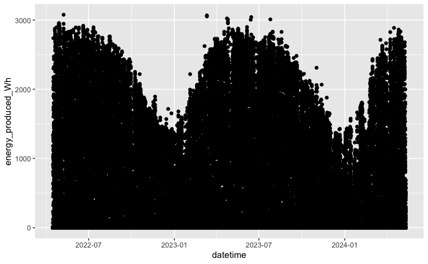

```r
ggplot(hourly_production, aes(datetime, energy_produced_Wh)) +
  geom_point()
```

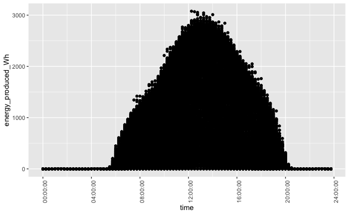

```r
ggplot(hourly_production, aes(time, energy_produced_Wh)) +
  theme(axis.text.x = element_text(angle = 90)) +
  geom_point()
```

Net + Produced = Consumed

```r
# hourly_ppl_net <- hourly_ppl_net %>% mutate(date = as_date(date))

#hourly_ppl_net %>% arrange(desc(date))
#hourly_production %>% arrange(desc(date))

(hourly_electricity <- hourly_ppl_net %>%
    inner_join(hourly_production, by = join_by(date,time))  %>%
    mutate(consumed_kWh = kWh + energy_produced_Wh/1000, produced_kWh = energy_produced_Wh/1000)  %>%
    rename(net_kWh = kWh) %>%
    select(datetime, date, time, net_kWh, produced_kWh, consumed_kWh) %>%
    arrange(date))
```

| datetime | date | time | net_kWh | produced_kWh | consumed_kWh |
| --- | --- | --- | --- | --- | --- |
| 2022-04-15 00:00:00 | 2022-04-15 | 00:00:00 | 0.06 | 0.000 | 0.060 |
| 2022-04-15 00:15:00 | 2022-04-15 | 00:15:00 | 0.07 | 0.000 | 0.070 |
| 2022-04-15 00:30:00 | 2022-04-15 | 00:30:00 | 0.05 | 0.000 | 0.050 |
| 2022-04-15 00:45:00 | 2022-04-15 | 00:45:00 | 0.09 | 0.000 | 0.090 |
| 2022-04-15 01:00:00 | 2022-04-15 | 01:00:00 | 0.08 | 0.000 | 0.080 |
| 2022-04-15 01:15:00 | 2022-04-15 | 01:15:00 | 0.09 | 0.000 | 0.090 |
| 2022-04-15 01:30:00 | 2022-04-15 | 01:30:00 | 0.08 | 0.000 | 0.080 |
| 2022-04-15 01:45:00 | 2022-04-15 | 01:45:00 | 0.08 | 0.000 | 0.080 |
| 2022-04-15 02:00:00 | 2022-04-15 | 02:00:00 | 0.05 | 0.000 | 0.050 |
| 2022-04-15 02:15:00 | 2022-04-15 | 02:15:00 | 0.07 | 0.000 | 0.070 |

[output cut: 990 more lines]

```r
NA
```

Calculate production for first year of solar panels, second year, etc.

| solar_year | net_kWh | produced_kWh | consumed_kWh |
| --- | --- | --- | --- |
| 1 | -997.56 | 18060.21 | 17062.65 |
| 2 | -1675.97 | 17141.23 | 15465.26 |

Interesting! Produced kWh went down by 5%, but consumed kWh went down by 10% despite the fact that we got an electric car! Let’s explore that further.

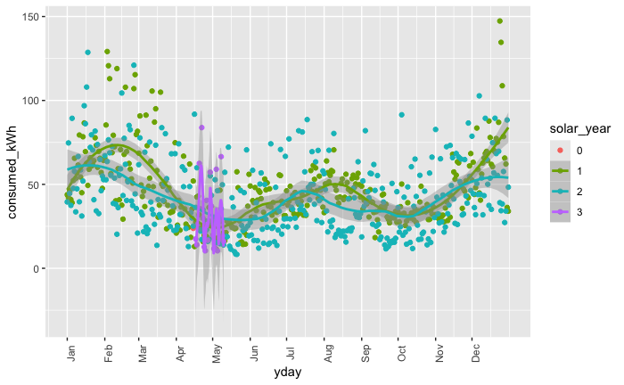

```r
daily_electricity <- hourly_electricity %>%
  group_by(solar_year, yday) %>%
  summarize(net_kWh = sum(net_kWh), produced_kWh = sum(produced_kWh), consumed_kWh = sum(consumed_kWh))
ggplot(daily_electricity, aes(yday, consumed_kWh, group=solar_year, color=solar_year)) +
  geom_point() +
  geom_smooth(span=0.3) +
  scale_x_continuous(breaks = c(1, 32, 60, 91, 121, 152, 182, 213, 244, 274, 305, 335), labels = month.abb) +
  theme(axis.text.x = element_text(angle = 90))
```

Daily totals

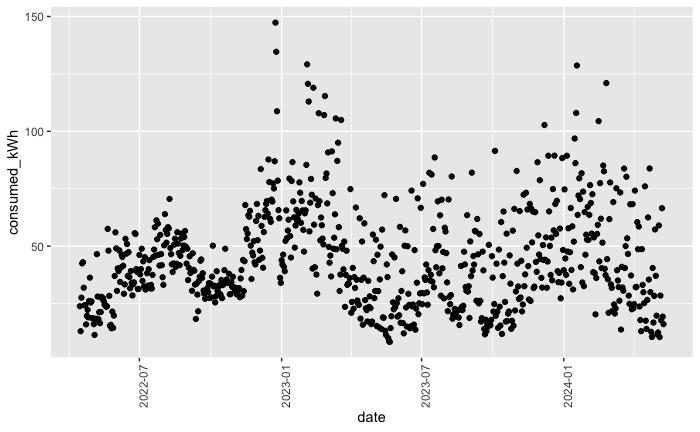

```r
daily_electricity <- hourly_electricity %>%
  mutate(solar_day = interval(as_date(as.POSIXct('04/15/2022',format="%m/%d/%Y",tz=Sys.timezone())),as_date(date)) / days(1)
         ) %>%
  group_by(date, solar_day) %>%
  summarize(net_kWh = sum(net_kWh), produced_kWh = sum(produced_kWh), consumed_kWh = sum(consumed_kWh))
ggplot(daily_electricity, aes(date, consumed_kWh)) +
  geom_point() +
  #scale_x_continuous(breaks = c(1, 32, 60, 91, 121, 152, 182, 213, 244, 274, 305, 335), labels = month.abb) +
  theme(axis.text.x = element_text(angle = 90))
```

```r
NA
NA
```

Look how our electricity consumption got much less predictable, more uneven, after we purchased an EV and installed a level 2 charger in late January/early February 2023!

Also, a couple of outlier high points in Dec 2022 before we got the EV… hmm.

We probably need to filter out the EV charging and compare that separately.

Average consumption based on time of day

```r
#hourly_electricity %>% summarize(min_date = min(date), max_date = max(date))

electricity_by_time <- hourly_electricity %>%
  filter(solar_year == 1 | solar_year == 2) %>%
  #filter(date <= as.POSIXct('12/31/2022 00:00',format="%m/%d/%Y %H:%M",tz=Sys.timezone()) ) %>%
  group_by(time, solar_year) %>%
  summarize(produced_kWh = mean(produced_kWh), consumed_kWh = mean(consumed_kWh), net_kWh = mean(net_kWh)) %>%
  arrange(time)
electricity_by_time
```

| time | solar_year | produced_kWh | consumed_kWh | net_kWh |
| --- | --- | --- | --- | --- |
| 00:00:00 | 1 | 0.000000e+00 | 0.3848767 | 0.384876712 |
| 00:00:00 | 2 | 0.000000e+00 | 0.5779781 | 0.577978142 |
| 00:15:00 | 1 | 0.000000e+00 | 0.3649315 | 0.364931507 |
| 00:15:00 | 2 | 0.000000e+00 | 0.5340164 | 0.534016393 |
| 00:30:00 | 1 | 0.000000e+00 | 0.3747397 | 0.374739726 |
| 00:30:00 | 2 | 0.000000e+00 | 0.5013661 | 0.501366120 |
| 00:45:00 | 1 | 0.000000e+00 | 0.3807123 | 0.380712329 |
| 00:45:00 | 2 | 0.000000e+00 | 0.4832240 | 0.483224044 |
| 01:00:00 | 1 | 0.000000e+00 | 0.3777322 | 0.377732240 |
| 01:00:00 | 2 | 0.000000e+00 | 0.4316894 | 0.431689373 |

[output cut: 182 more lines]

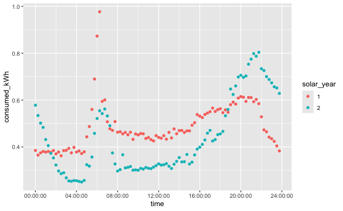

```r
ggplot(electricity_by_time, aes(x=time, y=consumed_kWh, group=solar_year, color=solar_year)) +
  geom_point()
```

```r
  #labs(colour="",x="Time of Day",y="Electricity Consumption (kWh)")+
  #scale_color_manual(values = c("red","black","green")) +
  #ggtitle("Home Electricity in 15-Minute Intervals (Since April 15, 2022)")
```

Is this due to milder weather?

Let’s look at it by month:

```r
#electricity_by_month <-
hourly_electricity %>%
  mutate(month = month(date)) %>%
  group_by(solar_year, month) %>%
  summarize(consumed_kWh = mean(consumed_kWh)) %>%
  arrange(month, solar_year) %>%
  pivot_wider(names_from = month, values_from = consumed_kWh) %>%
  arrange(solar_year)
```

| solar_year | 1 | 2 | 3 | 4 | 5 | 6 | 7 | 8 | 9 | 10 | 11 | 12 |
| --- | --- | --- | --- | --- | --- | --- | --- | --- | --- | --- | --- | --- |
| 0 | NA | NA | NA | 0.2480938 | NA | NA | NA | NA | NA | NA | NA | NA |
| 1 | 0.6229630 | 0.7793199 | 0.5868836 | 0.3196681 | 0.2636559 | 0.4176174 | 0.4433794 | 0.5227386 | 0.3624792 | 0.3524829 | 0.4634934 | 0.7247483 |
| 2 | 0.6408582 | 0.5985704 | 0.4467113 | 0.3611646 | 0.3107806 | 0.3359837 | 0.4866828 | 0.3373189 | 0.3565403 | 0.3480712 | 0.5000808 | 0.5625659 |
| 3 | NA | NA | NA | 0.3419333 | 0.2794468 | NA | NA | NA | NA | NA | NA | NA |

```r
#Look at limited window during day (no EV charging)

# hourly_electricity %>%
#   filter(time == '12:00:00') %>%
#   #filter(time > as.POSIXct('04:00:00',format="%H:%M:$s",tz=Sys.timezone()) ) %>%  #& time < as.POSIXct('18:00',format="%H:%M",tz=Sys.timezone())) %>%
#   mutate(month = month(date)) %>%
#   group_by(solar_year, month) %>%
#   summarize(consumed_kWh = mean(consumed_kWh)) %>%
#   arrange(month, solar_year) %>%
#   pivot_wider(names_from = month, values_from = consumed_kWh) %>%
#   arrange(solar_year)
```

Look at specific months

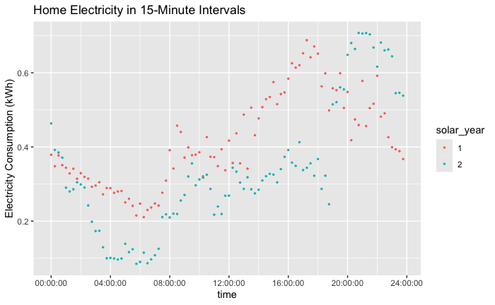

```r
electricity_by_month_time <- hourly_electricity %>%
  mutate(month = as_factor(month(date))) %>%
  filter(solar_year == 1 | solar_year == 2) %>%
  #Sample month
  filter(month == 6) %>%
  group_by(solar_year, month, time) %>%
  summarize(produced_kWh = mean(produced_kWh), consumed_kWh = mean(consumed_kWh), net_kWh = mean(net_kWh)) %>%
  arrange(solar_year, month, time)
ggplot(electricity_by_month_time, aes(time, consumed_kWh, group=solar_year, color=solar_year)) +
  #facet_grid(rows = vars(month)) +
  geom_point(size=0.5) +
  ggtitle("Home Electricity in 15-Minute Intervals") +
  ylab("Electricity Consumption (kWh)")
```

Example day with EV charging

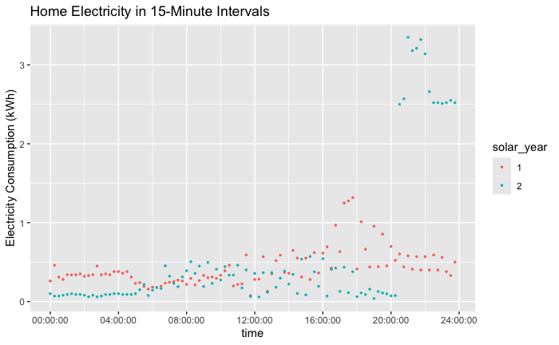

```r
sample_day <- hourly_electricity %>%
  filter(solar_year == 1 | solar_year == 2) %>%
  filter(yday == 161) %>%
  group_by(date, solar_year, yday, time) %>%
  summarize(produced_kWh = mean(produced_kWh), consumed_kWh = mean(consumed_kWh), net_kWh = mean(net_kWh)) %>%
  arrange(date, solar_year, yday, time)
ggplot(sample_day, aes(time, consumed_kWh, group=solar_year, color=solar_year)) +
  #facet_grid(rows = vars(month)) +
  geom_point(size=0.5) +
  ggtitle("Home Electricity in 15-Minute Intervals") +
  ylab("Electricity Consumption (kWh)")
```

Ok, let’s detect and remove EV charging sessions.

Bayesian change point example

```r
# library(onlineBcp)
x <- c(rnorm(10, 2.6, 0.2), rnorm(1, 2.6/2, 0.2) + rnorm(1, .2, .15), rnorm(86, .2, .15))
bcp <- online_cp(x)
summary(bcp)
```

```
[1] "Change points"
```

| location | post.prob |
| --- | --- |
| 11 | 0.6111704 |

```
[1] "Segments"
     begin end      mean        SD  LL of CI UL of CI
[1,]     1  11 2.4159210 0.2461319 2.2938538 2.537988
[2,]    12  97 0.2128337 0.1483191 0.1865265 0.239141
```

```r
bcp
```

[output not shown]

[output cut: 112 more lines]

Test on electricity consumption data

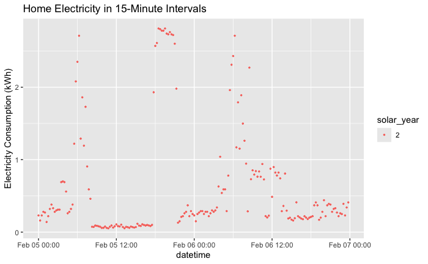

```r
# library(onlineBcp)

#Select a sample to test
sample <- hourly_electricity %>%
  mutate(solar_day = interval(as_date(as.POSIXct('04/15/2022',format="%m/%d/%Y",tz=Sys.timezone())),as_date(date)) / days(1) ) %>%
  filter(solar_year == 2) %>%
  filter(yday < 38 & yday > 35)

ggplot(sample, aes(datetime, consumed_kWh, group=solar_year, color=solar_year)) +
  #facet_grid(rows = vars(month)) +
  geom_point(size=0.5) +
  ggtitle("Home Electricity in 15-Minute Intervals") +
  ylab("Electricity Consumption (kWh)")
```

bcp model comparisons: https://lindeloev.github.io/mcp/articles/packages.html

```
[1] "Change points"
```

| location | post.prob |
| --- | --- |
| 22 | 0.6080293 |
| 71 | 0.8698735 |
| 86 | 0.6159300 |
| 118 | 0.5115733 |
| 131 | 0.5174379 |

```
[1] "Segments"
     begin end      mean        SD  LL of CI  UL of CI
[1,]     1  22 0.3472727 0.1636542 0.2898818 0.4046636
[2,]    23  71 0.3963061 0.6793674 0.2366690 0.5559433
[3,]    72  86 2.6233333 0.2818983 2.5036113 2.7430554
[4,]    87 118 0.3384375 0.1960597 0.2814289 0.3954461
[5,]   119 131 1.6671538 0.6909474 1.3519434 1.9823643
[6,]   132 192 0.4151148 0.2525212 0.3619333 0.4682962
```

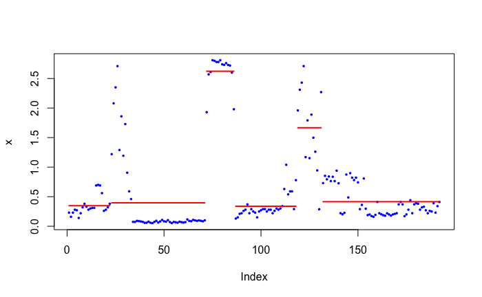

```r
min_time <- pull(sample %>% summarize(min_time = min(datetime)))

sample <- sample %>% mutate(time_x = interval(min_time,datetime)/minutes(15)+1)

#Filter data to feed to model
x <- sample %>%
  ungroup() %>%
  select(consumed_kWh)

x <- x$consumed_kWh

#Run online Bayesian Change Point model
#"Online" means in progress, not retroactive
bcp <- online_cp(x)

plot(summary(bcp))
```

Not too bad! It picks up the EV charging sessions, but it also picks up some other, presumably HVAC-related consumption changes. It looks like I should be able to weed these out easily.

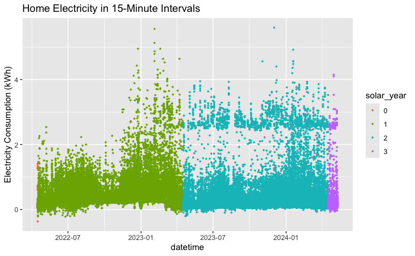

```r
#Select a sample to test
sample <- hourly_electricity %>%
  #filter(solar_year == 2) %>%
  mutate(solar_day = interval(as_date(as.POSIXct('04/15/2022',format="%m/%d/%Y",tz=Sys.timezone())),as_date(date)) / days(1) )

ggplot(sample, aes(datetime, consumed_kWh, group=solar_year, color=solar_year)) +
  #facet_grid(rows = vars(month)) +
  geom_point(size=0.5) +
  ggtitle("Home Electricity in 15-Minute Intervals") +
  ylab("Electricity Consumption (kWh)")
```

You can pick out our family vacation in August, and you can also see a period of high electricity usage in February, presumably related to cold weather. - Verify with weather data?

```r
min_time <- pull(sample %>% summarize(min_time = min(datetime)))

sample <- sample %>%
  mutate(time_x = interval(min_time,datetime)/minutes(15)+1)

#Filter data to feed to model
x <- sample %>%
  ungroup() %>%
  select(consumed_kWh)

x <- x$consumed_kWh

#Run online Bayesian Change Point model
#"Online" means in progress, not retroactive
bcp <- online_cp(x)

summary(bcp)
```

```
[1] "Change points"
```

| location | post.prob |
| --- | --- |
| 68 | 0.5195485 |
| 89 | 0.5032935 |
| 233 | 0.8265167 |
| 240 | 0.5104402 |
| 408 | 0.5060341 |
| 410 | 0.6934602 |
| 524 | 0.5132480 |
| 526 | 0.5383793 |
| 599 | 0.5358911 |
| 602 | 0.6861893 |

[output cut: 943 more lines]

```
[1] "Segments"
       begin   end       mean         SD   LL of CI   UL of CI
  [1,]     1    68 0.11851471 0.05251481 0.10803969 0.12898972
  [2,]    69    89 0.70085714 0.55165300 0.50284875 0.89886553
  [3,]    90   233 0.14222917 0.09243684 0.12955874 0.15489959
  [4,]   234   240 0.91714286 0.55476224 0.57224926 1.26203645
  [5,]   241   408 0.37915476 0.27470555 0.34429375 0.41401578
  [6,]   409   410 1.73000000 0.66468037 0.95691880 2.50308120
  [7,]   411   524 0.45407895 0.32414913 0.40414226 0.50401563
  [8,]   525   526 1.84250000 0.59609102 1.14919420 2.53580580
  [9,]   527   599 0.17747945 0.06771880 0.16444253 0.19051638
 [10,]   600   602 1.19966667 0.60550007 0.62464948 1.77468385
 [11,]   603   696 0.22370213 0.15978499 0.19659401 0.25081024
 [12,]   697   724 0.26989286 0.26216920 0.18839805 0.35138766
 [13,]   725   792 0.21539706 0.23737175 0.16804904 0.26274508
```

[output cut: 154 more lines]

```
[1] "Change points"
```

| location | post.prob |
| --- | --- |
| 68 | 0.5195485 |
| 89 | 0.5032935 |
| 233 | 0.8265167 |
| 240 | 0.5104402 |
| 408 | 0.5060341 |
| 410 | 0.6934602 |
| 524 | 0.5132480 |
| 526 | 0.5383793 |
| 599 | 0.5358911 |
| 602 | 0.6861893 |

[output cut: 943 more lines]

```
[1] "Segments"
       begin   end       mean         SD   LL of CI   UL of CI
  [1,]     1    68 0.11851471 0.05251481 0.10803969 0.12898972
  [2,]    69    89 0.70085714 0.55165300 0.50284875 0.89886553
  [3,]    90   233 0.14222917 0.09243684 0.12955874 0.15489959
  [4,]   234   240 0.91714286 0.55476224 0.57224926 1.26203645
  [5,]   241   408 0.37915476 0.27470555 0.34429375 0.41401578
  [6,]   409   410 1.73000000 0.66468037 0.95691880 2.50308120
  [7,]   411   524 0.45407895 0.32414913 0.40414226 0.50401563
  [8,]   525   526 1.84250000 0.59609102 1.14919420 2.53580580
  [9,]   527   599 0.17747945 0.06771880 0.16444253 0.19051638
 [10,]   600   602 1.19966667 0.60550007 0.62464948 1.77468385
 [11,]   603   696 0.22370213 0.15978499 0.19659401 0.25081024
 [12,]   697   724 0.26989286 0.26216920 0.18839805 0.35138766
 [13,]   725   792 0.21539706 0.23737175 0.16804904 0.26274508
```

[output cut: 154 more lines]

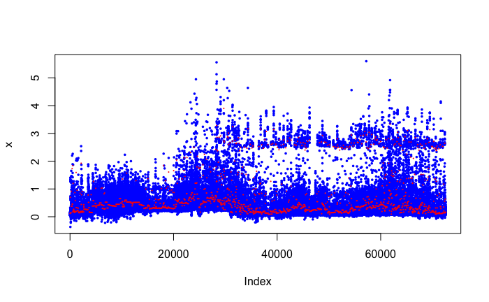

```r
plot(summary(bcp))
```

Nice! Looks like it still works over a longer period. (An advantage of an onlineBcp model?)

It looks like any interval with a mean above about 2.0 kWh should qualify as an EV charging session. - Do we need to do anything to avoid mixups with high HVAC usage? - Do we need to put an ideal length of charge on the intervals? Maximum variation during the period? - Use post.prob to filter out any intervals?

```r
result <- summary(bcp, norm.test = TRUE)
```

```
[1] "Change points"
```

| location | post.prob |
| --- | --- |
| 68 | 0.5195485 |
| 89 | 0.5032935 |
| 233 | 0.8265167 |
| 240 | 0.5104402 |
| 408 | 0.5060341 |
| 410 | 0.6934602 |
| 524 | 0.5132480 |
| 526 | 0.5383793 |
| 599 | 0.5358911 |
| 602 | 0.6861893 |

[output cut: 943 more lines]

```
[1] "Segments"
       begin   end       mean         SD   LL of CI   UL of CI normality p-value
  [1,]     1    68 0.11851471 0.05251481 0.10803969 0.12898972      5.558635e-02
  [2,]    69    89 0.70085714 0.55165300 0.50284875 0.89886553      2.356642e-01
  [3,]    90   233 0.14222917 0.09243684 0.12955874 0.15489959      5.017888e-02
  [4,]   234   240 0.91714286 0.55476224 0.57224926 1.26203645      8.598808e-01
  [5,]   241   408 0.37915476 0.27470555 0.34429375 0.41401578      2.983556e-05
  [6,]   409   410 1.73000000 0.66468037 0.95691880 2.50308120      9.991595e-01
  [7,]   411   524 0.45407895 0.32414913 0.40414226 0.50401563      1.754392e-03
  [8,]   525   526 1.84250000 0.59609102 1.14919420 2.53580580      9.991595e-01
  [9,]   527   599 0.17747945 0.06771880 0.16444253 0.19051638      2.609959e-02
 [10,]   600   602 1.19966667 0.60550007 0.62464948 1.77468385      9.460188e-01
 [11,]   603   696 0.22370213 0.15978499 0.19659401 0.25081024      2.906650e-04
 [12,]   697   724 0.26989286 0.26216920 0.18839805 0.35138766      1.914599e-02
 [13,]   725   792 0.21539706 0.23737175 0.16804904 0.26274508      1.569400e-04
```

[output cut: 130 more lines]

```r
bcp_segments <- as_tibble(result$result$segment) %>%
  mutate(length = end - begin) %>%
  mutate(lag_mean = lag(mean,1)) %>%
  mutate(lead_mean = lead(mean,1)) %>%
  mutate(adj = (lag_mean+lead_mean)/2)

bcp_segments %>%
  filter(mean > 2.0)
```

| begin | end | mean | SD | LL of CI | UL of CI | normality p-value | length | lag_mean | lead_mean | adj |
| --- | --- | --- | --- | --- | --- | --- | --- | --- | --- | --- |
| 20570 | 20578 | 2.040889 | 0.63784823 | 1.6911666 | 2.390611 | 0.6135144240 | 8 | 0.44713187 | 0.57975352 | 0.5134427 |
| 22066 | 22076 | 2.124545 | 0.30907487 | 1.9712622 | 2.277829 | 0.6166967744 | 10 | 0.64341176 | 0.40588235 | 0.5246471 |
| 22586 | 22592 | 2.131429 | 0.88407067 | 1.5818052 | 2.681052 | 0.9789364642 | 6 | 0.83026882 | 0.48131250 | 0.6557907 |
| 23259 | 23264 | 2.313333 | 0.96346597 | 1.6663576 | 2.960309 | 0.7594530398 | 5 | 0.69570745 | 0.55220652 | 0.6239570 |
| 23931 | 23936 | 2.500000 | 0.65007692 | 2.0634677 | 2.936532 | 0.9302687348 | 5 | 0.72294681 | 0.60047826 | 0.6617125 |
| 24602 | 24608 | 2.177143 | 0.60947284 | 1.7982359 | 2.556050 | 0.7095222511 | 6 | 0.81529730 | 0.64849296 | 0.7318951 |
| 25948 | 25952 | 2.242000 | 0.50355735 | 1.8715828 | 2.612417 | 0.6424792211 | 4 | 0.54457500 | 0.52030952 | 0.5324423 |
| 26331 | 26334 | 2.070000 | 1.03327957 | 1.2202032 | 2.919797 | 0.9362632776 | 3 | 0.52574211 | 0.85352632 | 0.6896342 |
| 28154 | 28158 | 2.420000 | 0.61094190 | 1.9705906 | 2.869409 | 0.9765261684 | 4 | 0.75911702 | 0.75935185 | 0.7592344 |
| 28298 | 28310 | 3.282308 | 1.36175226 | 2.6610759 | 3.903540 | 0.7818417752 | 12 | 1.26385714 | 1.27920588 | 1.2715315 |

[output cut: 157 more lines]

```r
NA
```

```r
sample_adj <-  sample %>%
  left_join(bcp_segments, by = join_by(time_x>=begin,time_x<=end)) %>%
  mutate(consumed_kWh_adj = case_when(
                                mean > 2.0 & mean < 3.0 ~ consumed_kWh - (mean - adj),
                                .default = consumed_kWh
                                )
         )

sample_adj
```

[output not shown]

[output cut: 990 more lines]

```r
NA
NA
```

Re-run on all three years, count charging sessions by month/year